### Part II

#### Solution

Tuesday, May 21, 2013

**1.** A consumer group wishes to test the longevity of various brands of lightbulbs. A random sample of $6$ bulbs from each of the four given brands’ production were chosen and lightbulbs were burnt until they failed. here are the results (numbers are hours that the bulb lasted). Data can be found in the file `ob_prob_bulbs.txt`.

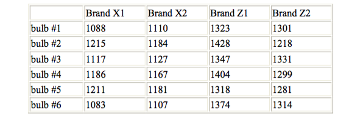

1. [4 points] We wish to test whether the mean longevity differs significantly from brand to brand. Write the appropriate ANOVA model: include the equation, ranges of subscripts, restriction of the parameters and distributional assumptions.
   **Solution**
   Model:
   $$Y_{ij} = \mu + \alpha_i + \varepsilon_{ij}, \ \ \ i=1,2,3,4 \ \text{and} \ j=1,2, \dots, 6$$
   where $\varepsilon \stackrel{iid}{\sim} N(0, \sigma)$.
   “It is common, but not necessary, to impose the restriction that $\sum_i \alpha_i = 0$.”
   “The residuals are normally distributed with equal variance.”
2. [5 points] State the appropriate null and alternative hypotheses and perform the appropriate test. What is the P-value? Use 5% level of significance.  
   **Solution**  
   $H_0: \mu_{X2} = \mu_{X2} = \mu_{Z1} = \mu_{Z2}$  
   $H_a:$ at least one brand is different.  
   “With the restriction succested in part(a) we can state these as $H_0: \alpha_1=\alpha_2=\alpha_3=\alpha_4$ and $H_a$: at least one $\alpha_i$ is not $0$.”

```r
raw.text <- "
time
1088
1215
1117
1186
1211
1083
1110
1184
1127
1167
1181
1107
1323
1428
1347
1404
1318
1374
1301
1218
1331
1299
1281
1314
"
bulb.df <- read.table(header=TRUE, text=raw.text)
bulb.df$brand <- factor(rep(x=c("X1", "X2", "Z1", "Z2"), times=1, each=6))

bulb.aov <- aov(formula=time ~ brand, data=bulb.df)
summary(bulb.aov)
```

```
##             Df Sum Sq Mean Sq F value   Pr(>F)
## brand        3 211683   70561   33.17 5.86e-08 ***
## Residuals   20  42539    2127
## ---
## Signif. codes:  0 '***' 0.001 '**' 0.01 '*' 0.05 '.' 0.1 ' ' 1
```

*p*-value < 0.001. Reject $H_0$ at $\alpha=0.05$.

3. [4 points] What pattern of differences do you find using Fisher’s LSD method? Specifically, what is the numerical value of the least significant difference? Make an underline diagram.  
   **Solution**

```r
library(agricolae)
LSD.bulb <- LSD.test(y=bulb.aov, trt="brand")
LSD.bulb$groups
```

```
##   trt    means M
## 1  Z1 1365.667 a
## 2  Z2 1290.667 b
## 3  X1 1150.000 c
## 4  X2 1146.000 c
```

Brands X1 and X2 are similar to each other and different from the other two brands. Brands Z1 and Z2 are in their own individual groups.

```r
LSD.bulb$statistics
```

```
##       Mean       CV  MSerror      LSD
##   1238.083 3.725007 2126.933 55.54219
```

The numerical value of the LSD is 55.54.

4. [8 points] Additional information is that Brand $X1$ and Brand $X2$ are manufactured at Factory $X$; Brand $Z1$ and Brand $Z2$ are manufactured at Factory $Z$. With this additional information, perform the analysis according to an appropriately revised model. Write down the appropriate ANOVA model and discuss results.  
   **Solution**  
   “This is nested design. Check for factory difference, as well as two brands under each factory.” The two factors are fixed effects.

```r
bulb.df$factory <- ifelse(test=bulb.df$brand=="X1" | bulb.df$brand=="X2", yes="X", no="Z")
bulb.df$factory <- factor(bulb.df$factory)
bulb.nest <- aov(formula=time ~ factory + factory/brand, data=bulb.df)  # nested and fixed effect
# aov(formula=time ~ factory + brand %in% factory, data=bulb.df) # equivalent nested model

#
# aov(formula=time ~ factory + factory:brand, data=bulb.df) # equivalent nested model
# nesting amounts to adding one main effect and one interaction.
#
anova(bulb.nest)
```

```
## Analysis of Variance Table
##
## Response: time
##               Df Sum Sq Mean Sq F value  Pr(>F)
## factory        1 194760  194760 91.5685 6.6e-09 ***
## factory:brand  2  16923    8462  3.9783 0.03511 *
## Residuals     20  42539    2127
## ---
## Signif. codes:  0 '***' 0.001 '**' 0.01 '*' 0.05 '.' 0.1 ' ' 1
```

5. [4 points] Check for your model (from d) assumptions.  
   **Solution**  
   Normality:

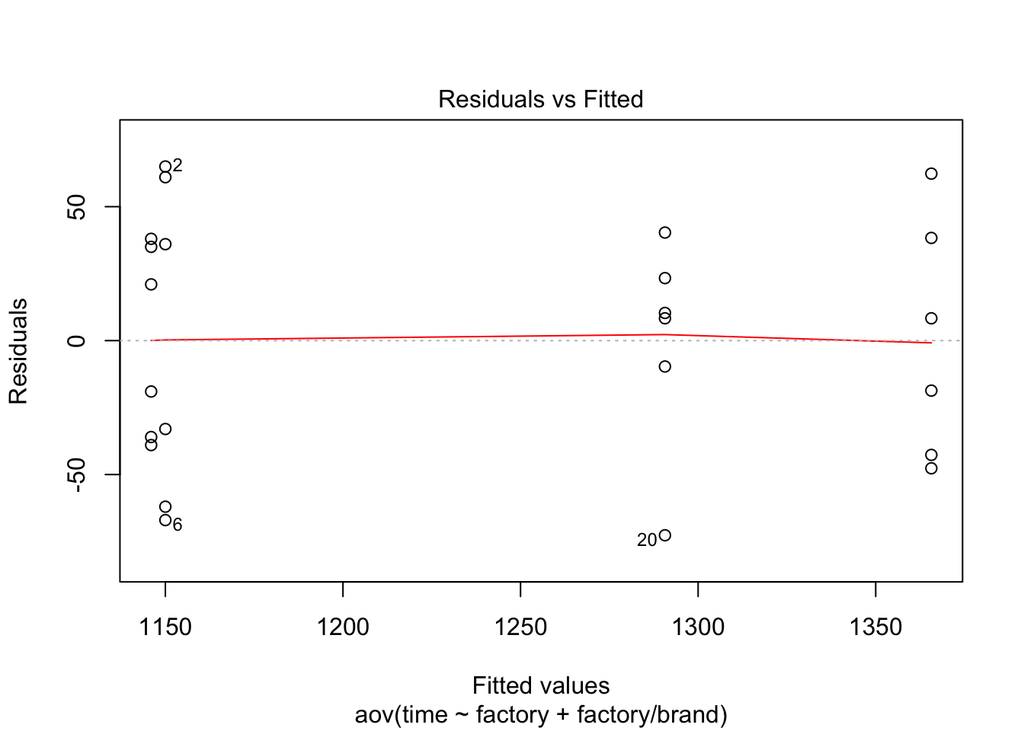

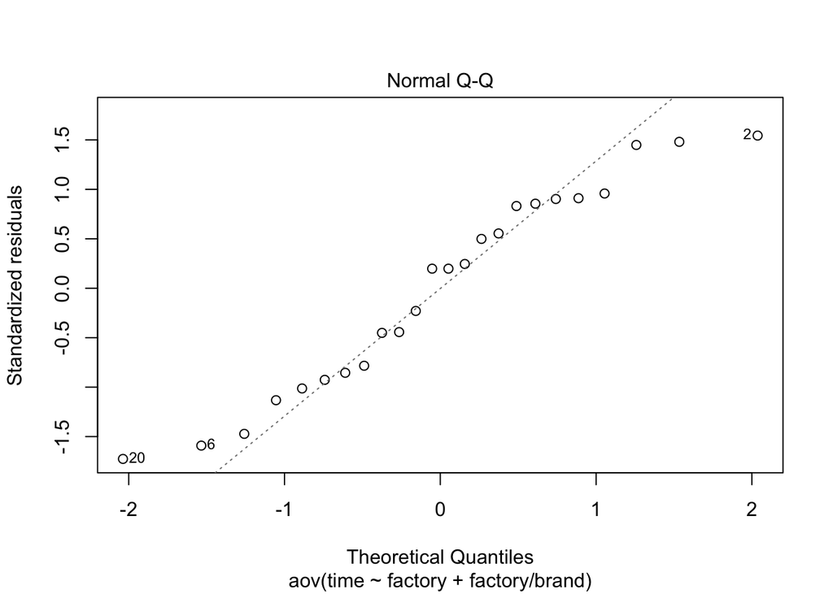

```r
plot(bulb.nest, which=c(1,2))
```

Constant Variance:

```r
bartlett.test(time ~ brand, data=bulb.df)
```

```
##
##  Bartlett test of homogeneity of variances
##
## data:  time by brand
## Bartlett's K-squared = 1.6533, df = 3, p-value = 0.6474
```

```r
#fligner.test(time ~ brand, data=bulb.df)
library(car)
leveneTest(y=time ~ brand, center=median, data=bulb.df) # aka BFL test
```

```
## Levene's Test for Homogeneity of Variance (center = median)
##       Df F value Pr(>F)
## group  3  2.2841   0.11
##       20
```

Not sure how to do test for a nested model. Results of this output matches solution, however.